# Introduction to Python Project : FoodHub Data Analysis

### Food preparation time for different cuisine type

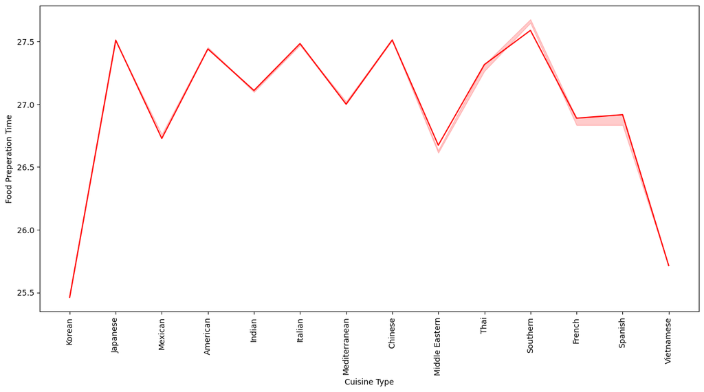

```python
plt.figure(figsize = (15,7))
sns.lineplot(data = df, x = "cuisine_type", y = "food_preparation_time", errorbar = ("ci" ,True) , color="red")
plt.xticks(rotation = 90)
plt.xlabel("Cuisine Type")
plt.ylabel("Food Preperation Time")
plt.show()
```

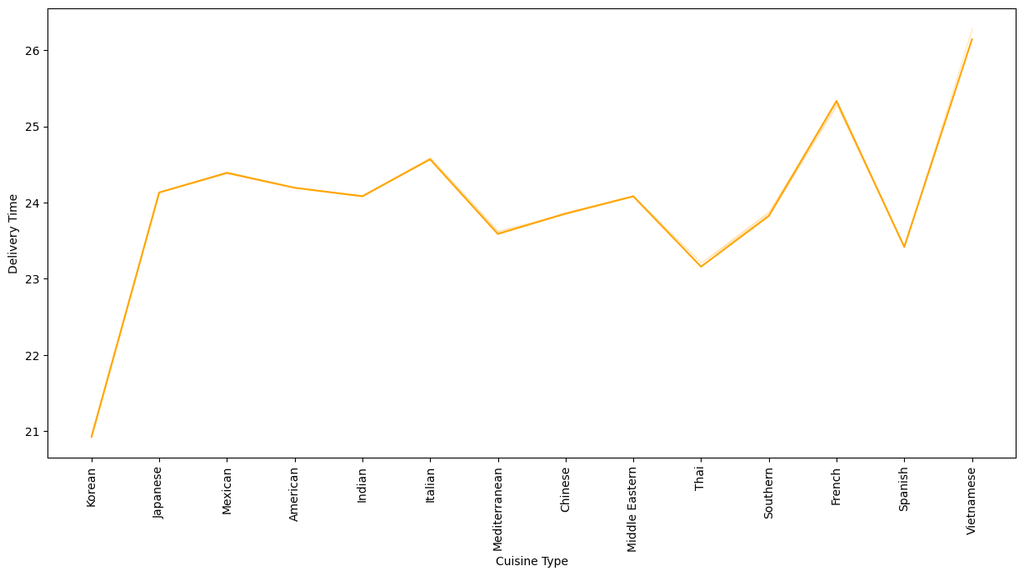

```python
plt.figure(figsize = (15,7))
sns.lineplot(data = df, x = "cuisine_type", y = "delivery_time", errorbar = ("ci" ,True), color="orange")
plt.xticks(rotation = 90)
plt.xlabel("Cuisine Type")
plt.ylabel("Delivery Time")
plt.show()
```

### Cost of order with food preperation time relation

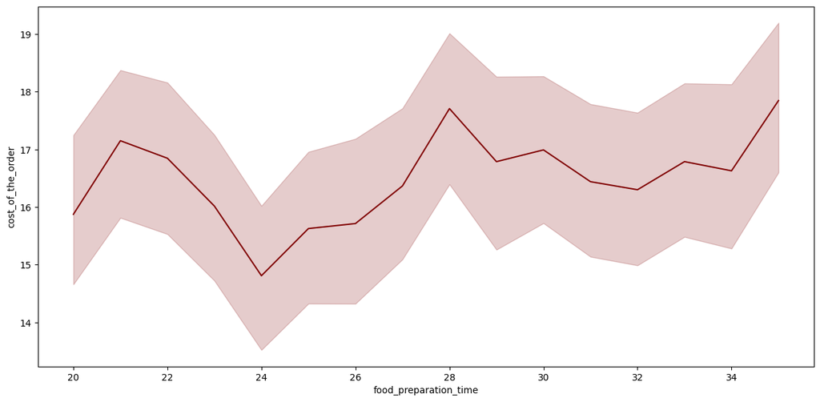

```python
plt.figure(figsize = (15,7))
sns.lineplot(data = df, y = "cost_of_the_order", x = "food_preparation_time", color = "Maroon")
plt.show()
```

### Cost of order with food delivery time relation

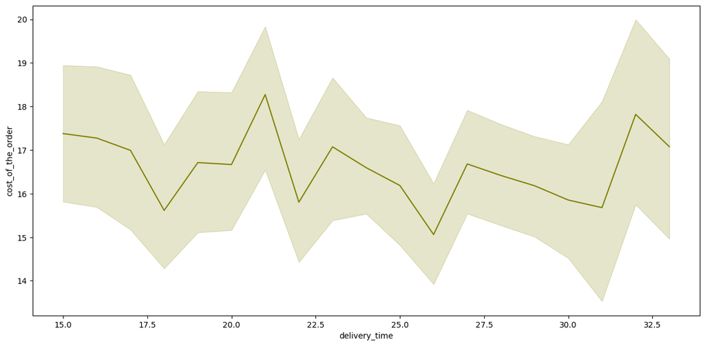

```python
plt.figure(figsize = (15,7))
sns.lineplot(data = df, y = "cost_of_the_order", x = "delivery_time", color = "Olive")
plt.show()
```

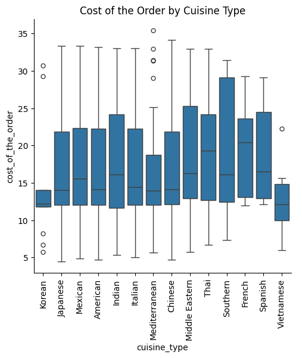

```python
sns.catplot(x='cuisine_type', y='cost_of_the_order', data=df, kind='box')
plt.title('Cost of the Order by Cuisine Type')
plt.xticks(rotation=90)
plt.show()
```

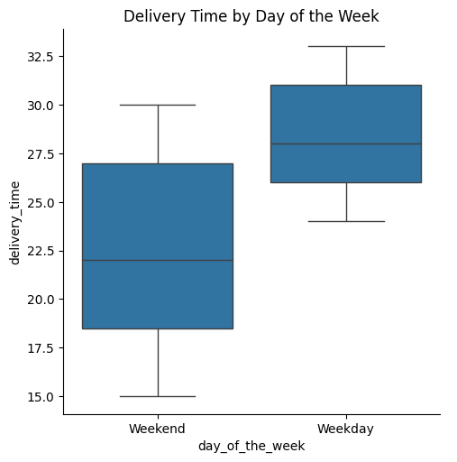

```python
sns.catplot(x='day_of_the_week', y='delivery_time', data=df, kind='box')
plt.title('Delivery Time by Day of the Week')
plt.show()
```

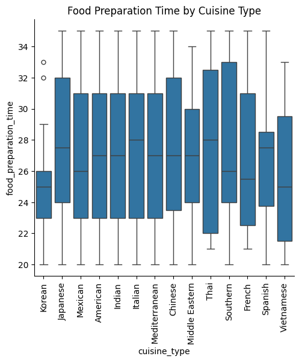

```python
sns.catplot(x='cuisine_type', y='food_preparation_time', data=df, kind='box')
plt.title('Food Preparation Time by Cuisine Type')
plt.xticks(rotation=90)
plt.show()
```

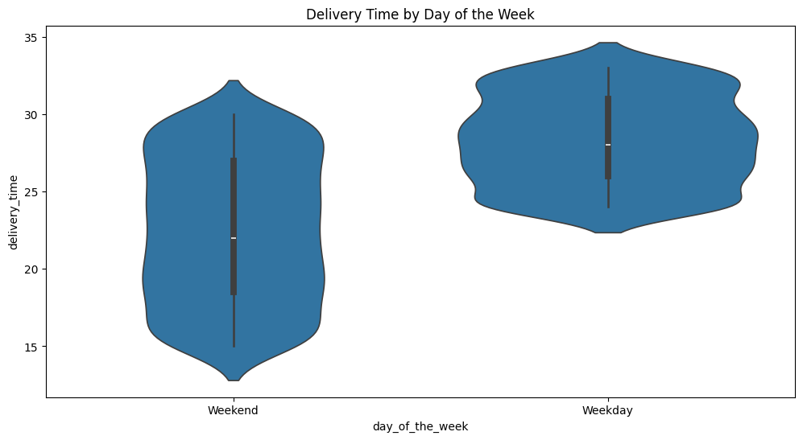

```python
plt.figure(figsize=(12, 6))
sns.violinplot(x='day_of_the_week', y='delivery_time', data=df)
plt.title('Delivery Time by Day of the Week')
plt.show()
```

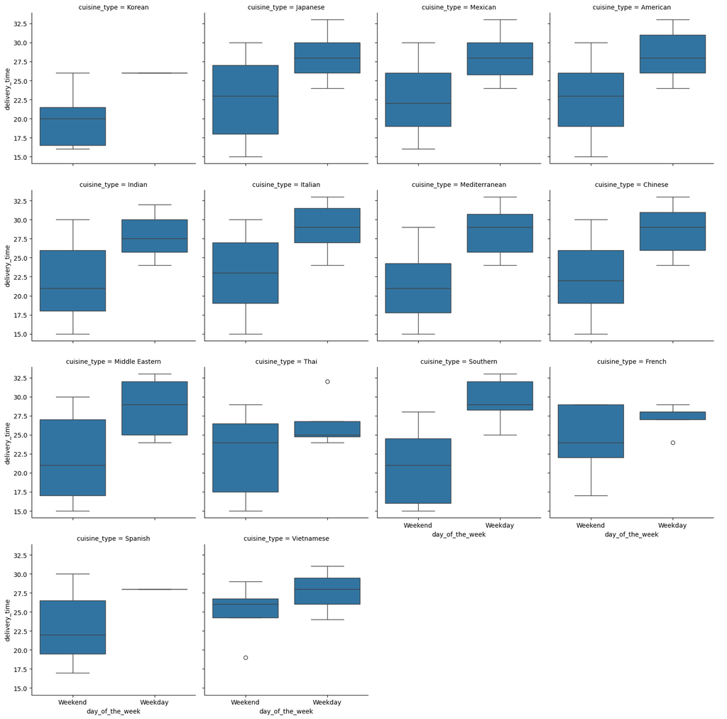

```python
g = sns.FacetGrid(df, col='cuisine_type', col_wrap=4, height=4)
g.map(sns.boxplot, 'day_of_the_week', 'delivery_time')
g.add_legend()
plt.show()
```

### **Question 13:** The company wants to provide a promotional offer in the advertisement of the restaurants. The condition to get the offer is that the restaurants must have a rating count of more than 50 and the average rating should be greater than 4. Find the restaurants fulfilling the criteria to get the promotional offer. [3 marks]

```python
# Filter out rows with 'Not given' ratings, assuming they are not useful for average rating calculation
data_filtered = df[df['rating'] != 'Not given']

# Convert the rating column to numeric
data_filtered['rating'] = (data_filtered['rating']).astype(int)

# Group by restaurant name and calculate the rating count and average rating
restaurant_stats = data_filtered.groupby('restaurant_name').agg(rating_count=('rating', 'size'), avg_rating=('rating', 'mean')).reset_index()

# Filter restaurants based on the conditions
promotional_restaurants = restaurant_stats[(restaurant_stats['rating_count'] > 50) & (restaurant_stats['avg_rating'] > 4)]

print(promotional_restaurants)
```

```
               restaurant_name  rating_count  avg_rating
16   Blue Ribbon Fried Chicken            64    4.328125
17           Blue Ribbon Sushi            73    4.219178
117                Shake Shack           133    4.278195
132          The Meatball Shop            84    4.511905
```

#### Observations:

- Company needs to provide a promotional offer in the advertisement for restaurants:`Blue Ribbon Fried Chicken`, `Blue Ribbon Sushi`, `Shake Shack`, `The Meatball Shop`

### **Question 14:** The company charges the restaurant 25% on the orders having cost greater than 20 dollars and 15% on the orders having cost greater than 5 dollars. Find the net revenue generated by the company across all orders. [3 marks]

```python
#Define the calculate revenue function
def calculate_revenue(order_cost):
    if order_cost > 20:
        return order_cost * 0.25
    elif order_cost > 5:
        return order_cost * 0.15
    else:
        return 0

#Apply the revenue calculation to each order
df['revenue'] = df['cost_of_the_order'].apply(calculate_revenue)

#Calculate the total revenue
total_revenue = df['revenue'].sum()
print(f"Total revenue generated by the company: ${total_revenue:.2f}")
```

```
Total revenue generated by the company: $6166.30
```

#### Observations:

- Net revenue generated by company across all orders are **$6166.30**

### **Question 15:** The company wants to analyze the total time required to deliver the food. What percentage of orders take more than 60 minutes to get delivered from the time the order is placed? (The food has to be prepared and then delivered.) [2 marks]

```python
#Total number of order
total_orders = df["order_id"].count()
total_orders

#Total time required to deliver food
Total_time_taken = df["food_preparation_time"] + df["delivery_time"]
Total_time_taken

#Delivery time more than 60 minutes
more_than_60_min = (Total_time_taken > 60).sum()
more_than_60_min

percentage_more_than_60_minutes = ((more_than_60_min / total_orders) * 100).round(2)
percentage_more_than_60_minutes
```

```
10.54
```

#### Observations:

- **10.54%** of orders took more than 60 minutes to get delivered from the time the order is placed.

### **Question 16:** The company wants to analyze the delivery time of the orders on weekdays and weekends. How does the mean delivery time vary during weekdays and weekends? [2 marks]

```python
df.groupby("day_of_the_week")["delivery_time"].mean("delivery_time").round(2)
```

```
day_of_the_week
Weekday    28.34
Weekend    22.47
Name: delivery_time, dtype: float64
```

#### Observations:

- The average delivery time of the orders on weekdays is **28.34** minutes and on weekends is **22.47** minutes.
- By looking above insights on weekends there is faster delivery than weekdays.

### Conclusion and Recommendations

### **Question 17:** What are your conclusions from the analysis? What recommendations would you like to share to help improve the business? (You can use cuisine type and feedback ratings to drive your business recommendations.) [6 marks]

### **Conclusions**:

```
Customer Preferences:
```

- High Ratings for Specific Cuisines: Certain cuisines may consistently receive higher average ratings compared to others. For example, Italian and Japanese cuisines might receive higher ratings due to their popularity and quality.
- Low Ratings for Specific Cuisines: Some cuisines might consistently receive lower ratings, indicating potential issues with the food quality, preparation, or customer expectations.

```
Order Patterns:
```

- Day of the Week Trends: There may be specific days of the week with higher order volumes, such as weekends, which could also correlate with different average ratings.
- Order Cost and Rating Relationship: Higher-cost orders might correlate with higher ratings, suggesting customers are willing to pay more for better quality or service.

```
Service Efficiency:
```

- Preparation and Delivery Time: The analysis might show a relationship between food preparation time, delivery time, and ratings. Longer preparation or delivery times could negatively impact ratings.

### **Recommendations**:

```
Focus on High-Rating Cuisines:
```

- Promotional Offers: Promote cuisines that receive high ratings more aggressively. Offer discounts or loyalty points to encourage repeat orders for these cuisines.
- Menu Expansion: Consider expanding the menu items for high-rating cuisines to cater to customer preferences and increase order volumes.

```
Improve Low-Rating Cuisines:
```

- Quality Control: Investigate the reasons behind low ratings for specific cuisines. Improve the quality of ingredients, preparation methods, or presentation.
- Customer Feedback: Collect detailed feedback from customers who rate these cuisines poorly to identify specific issues and address them.

```
Optimize Preparation and Delivery:
```

- Efficiency Improvements: Streamline food preparation and delivery processes to reduce times, especially for cuisines or dishes that currently have longer times.
- Real-Time Tracking: Implement real-time order tracking for customers to reduce anxiety and improve satisfaction, potentially improving ratings.

```
Targeted Marketing:
```

- Day-Specific Promotions: Offer special deals or discounts on days with typically lower order volumes to balance the demand throughout the week.
- Cost-Based Offers: Provide value-for-money deals for higher-cost items that are well-rated to attract more cost-conscious customers without compromising on quality.

```
Customer Loyalty Programs:
```

- Rewards for High Ratings: Introduce loyalty programs that reward customers for high ratings and detailed feedback, encouraging positive reviews and repeat business.
- Personalized Offers: Use customer data to provide personalized offers based on past order history and preferences, enhancing customer experience and satisfaction.

By focusing on these areas, the business can enhance customer satisfaction, improve the quality of offerings, and optimize operations to drive growth and profitability.